# Intro to ggplot2

23 December, 2020

## Welcome!

### SCR Week 05

## QA? Any questions?

- Asking questions via rteam@stat.leidenuniv.nl
- is good feedback for us to see how you’re doing
- Topic for explanation in the Live Coding XXL

## (Tentative) Schedule Today

**09.15 - 10.00**: `ggplot2`  
- talking / live coding / quiz

**10.15 - 11.00**: `ggplot2` continued  
- mainly (if not only) exercises

**11.15 - 12.00**: Live Coding XXL  
- Continuing exercise 5.4 –> 5.4d

**12.15 - 13.00**: No Class  
- we are available online until 13.00 (e.g. MS-Teams)

## A Tidyverse Topic

### Grammar of Graphics

## `ggplot2`: a tidyverse package

Although `ggplot2` is older than tidyverse, it is part of the

[Tidyverse manifesto](https://cran.r-project.org/web/packages/tidyverse/vignettes/manifesto.html):

`"Programs must be written for people to read, and only incidentally for machines to execute."`

`- Hal Abelson`

## The tidyverse: `help(package = "tidyverse")`

Core tidyverse: `ggplot2`, `dplyr`, `tidyr`, `readr`, `purrr`, `tibble`, `stringr`, `forcats`, which all have their own dependencies. See

https://www.tidyverse.org/packages/

Also check out the [popular R packages](https://www.crantastic.org/popcon).

## Grammar of Graphics: `ggplot2`

by courtesy of [Jennifer Bryan](https://github.com/jennybc/ggplot2-tutorial), [Hadley Wickham](https://github.com/hadley/ggplot2-book), and [Thomas de Beus](https://medium.com/tdebeus/think-about-the-grammar-of-graphics-when-improving-your-graphs-18e3744d8d18)

## Learning objectives

Use `ggplot2` functions, but avoid tweaking / programming these functions yourself.

- Obtain a head start to master your own `ggplot2` figures during your master.
- Recognize and code with `ggplot2` grammar elements in the Grammar of Graphics
- Apply geometries: `geom_point`, `geom_histogram`, `geom_boxplot`, and
- be ready to adapt to all other “`geom_*` layers”

## `ggplot2`

Hadley Wickham implemented the Grammar of Graphics (https://www.springer.com/us/book/9780387245447) based on the [book](https://www.springer.com/us/book/9780387245447) by [Leland Wilkinson](https://www.cs.uic.edu/~wilkinson/)

`ggplot2` is based on the `grid` package: a `ggplot` builds trees of (:= combines) many grid elements.

## Grammar of Graphics

Defines the components of a graph and structures graph-creation.

- **Statistical transformations** map from data to aesthetics of geometric objects
- **Geometric objects** define the visible objects (points, lines, …)
- **Aesthetics** map variables to scales for the geometric objects (color, fill, size, …)
- **Facets** separate the plot into multiple plots.

`ggplot2` is a translation of the grammar of graphics into R.

## The Data

```r
library(gapminder)
#?gapminder
str(gapminder)
```

```
## tibble [1,704 x 6] (S3: tbl_df/tbl/data.frame)
##  $ country  : Factor w/ 142 levels "Afghanistan",..: 1 1 1 1 1 1 1 1 1 1 ...
##  $ continent: Factor w/ 5 levels "Africa","Americas",..: 3 3 3 3 3 3 3 3 3 3 ...
##  $ year     : int [1:1704] 1952 1957 1962 1967 1972 1977 1982 1987 1992 1997 ...
##  $ lifeExp  : num [1:1704] 28.8 30.3 32 34 36.1 ...
##  $ pop      : int [1:1704] 8425333 9240934 10267083 11537966 13079460 14880372 12881816 13867957 16317921 22227415 ...
##  $ gdpPercap: num [1:1704] 779 821 853 836 740 ...
```

Check the Hans Rosling’s talks: https://www.gapminder.org/videos/

## 3 Essential Grammatical Elements

The function `ggplot()` contains:

1. Data = `gapminder`
2. Mapping := aesthetics = `aes()`

but does not contain a geometry

## The `ggplot()`

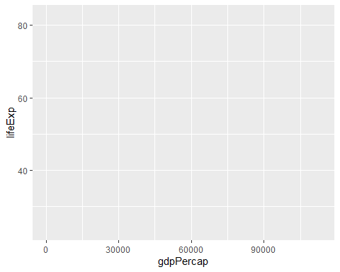

```r
p <- ggplot(data = gapminder, mapping = aes(x = gdpPercap, y = lifeExp))
p
```

## Adding Geometric Objects

In `ggplot2` we can add geometric objects via `geom_*`

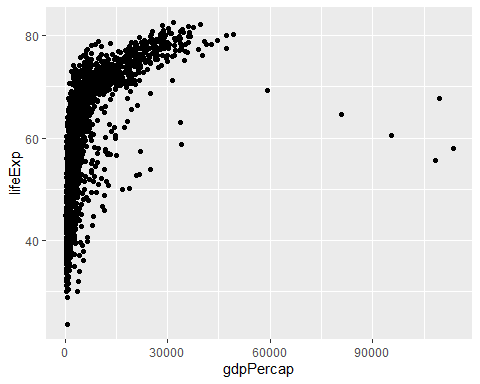

```r
p + geom_point()
```

## Many `graphics::par` still remain…

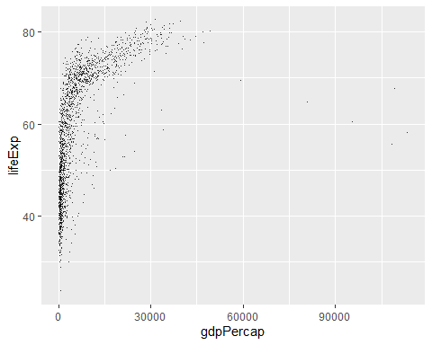

```r
p + geom_point(pch = ".", cex = 0.7, alpha = 0.8)
```

## `pch` and `cex` or `shape` and `size`?

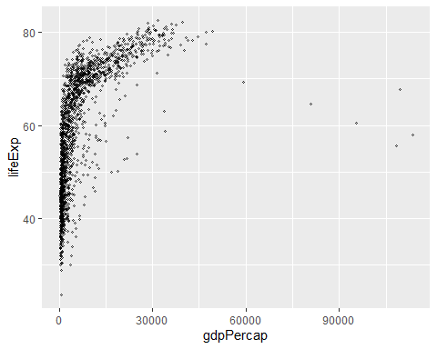

```r
p + geom_point(shape = 21, size = 0.7, alpha = 0.8)
```

## Axis transformation

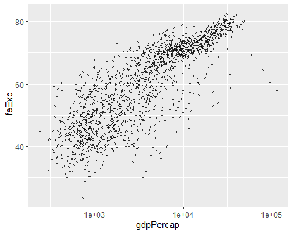

```r
p <- p + scale_x_log10()
p + geom_point(shape = 21, size = 0.7, alpha = 0.8)
```

## Map data to visual parameters: `aes()`

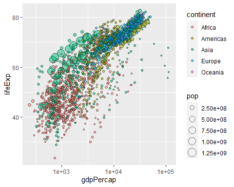

```r
p + geom_point(aes(size = pop, fill = continent), shape = 21, alpha = 0.5)
```

## Facets

```r
ggplot(gapminder, aes(x = year, y = lifeExp, col = gdpPercap)) +
  geom_jitter(aes(size = pop)) +
  scale_color_continuous(low = "blue", high = "red") +
  scale_x_log10() +
  stat_smooth(method = "loess", se = FALSE, col = "red", lwd = 0.5) +
  coord_cartesian(xlim = c(2000,2007)) +
  facet_wrap(~ continent, ncol = 5) +
  theme(
    legend.position = "bottom"
  )
```

## Facets

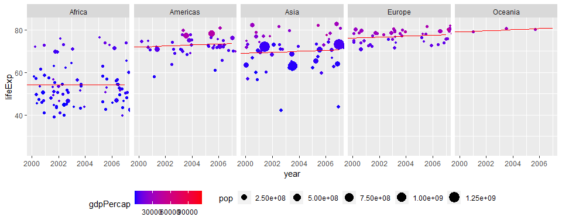

## Live Coding

[figure not shown]

## Extra grammatical elements

Apart from **data**, **aesthetics** and **geometries** we added the layers for

**Facet:** `facet_*`, e.g. `facet_grid()`  
- Plotting multiple plots, separated by variable(s)

**Statistics:** `stat_*`,  
- Statistical transformations of our data to aid understanding. Although it has less options, it is often interchangeable with its corresponding `geom_*`, e.g. `geom_smooth()`.

**Coordinates:** `coord_*`, e.g. `coord_flip()`  
- The space on which the data will be plotted.

**Theme:** `theme(.)`  
- customize the non-data components of your plot.

## Geometry Layers

### Histogram and 2DBind

[figure not shown]

## Histogram: A mixture of distributions?

```r
# data manipulations:
gapminder2007 <- gapminder[gapminder$year == 2007,]
lifeExp.mean <- mean(gapminder2007$lifeExp)
lifeExp.sd <- sd(gapminder2007$lifeExp)
```

## Histogram: A mixture of distributions?

```r
ggplot(gapminder2007, aes(x = lifeExp)) +
  geom_histogram(
    aes(y = stat(density)),
    bins = 10, fill = "lightblue", col = "black"
) +
  geom_density(
    aes(y = stat(density)),
    col = "blue"
  ) +
  stat_function(
    fun = dnorm, args = list(mean = lifeExp.mean, sd = lifeExp.sd),
    col = "red"
  )
```

## Histogram: A mixture of distributions?

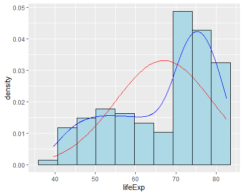

## Histogram

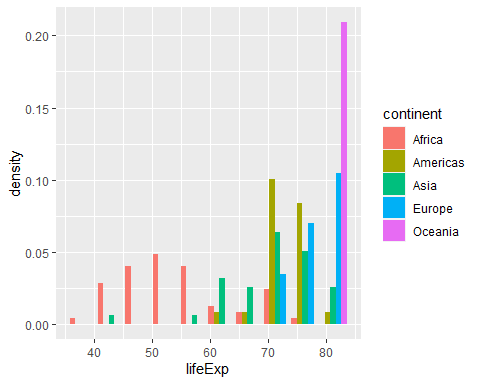

```r
ggplot(gapminder2007,
  aes(
    x = lifeExp,
    fill = continent
  )
) +
  geom_histogram(
    aes(y = stat(density)),
    position = "dodge",
    bins = 10
  )
```

## `geom_bin2d()`

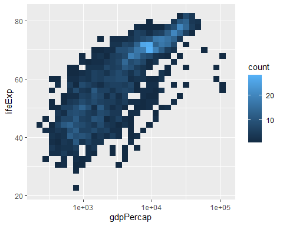

```r
ggplot(
  gapminder,
  aes(
    x = gdpPercap,
    y = lifeExp
  )
) +
scale_x_log10() +
geom_bin2d()
```

## Quiz

## Some details

[figure not shown]

## Some details you may want to use…

Instead of `par(mfrow = c(2, 3)` use either  
- `facet_grid()` or `facet_wrap()`  
- or `gridExtra::grid.arrange()`  
- or `cowplot::plot_grid()`

Like to change colors?  
- `scale_fill_manual()`, `scale_color_manual()`  
- or [more options](http://www.sthda.com/english/wiki/ggplot2-colors-how-to-change-colors-automatically-and-manually)

Another theme?  
- `ggplot` themes: `get_theme()`, `set_theme()`  
- check out [`devtools::install_github("jrnold/ggthemes")`](https://github.com/jrnold/ggthemes)

## `ggplot2` extensions

Another type of plot? Check the [GitHub tag](https://github.com/topics/ggplot-extension).

E.g.: `ggridges`

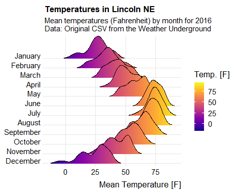

## `cowplot`

Cowplot is another opiniated package designed to “provide a publication-ready theme for ggplot2, one that requires a minimum amount of fiddling […]”.

[output not shown]

## Traditional

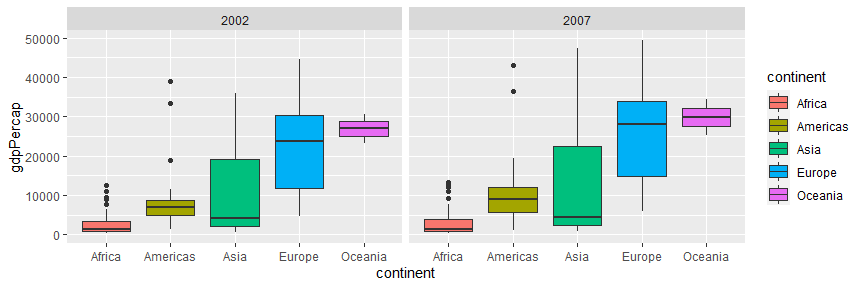

```r
library(ggplot2)
ggplot(gapminder_modern, aes(x = continent, y = gdpPercap, fill = continent)) +
  geom_boxplot(position = "dodge") +
  facet_wrap(~ year)
```

## Cowplot

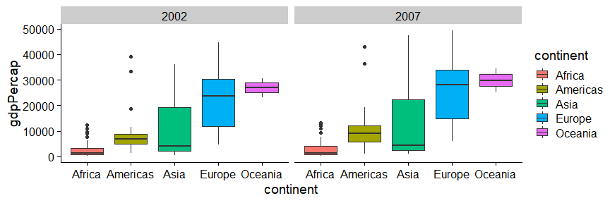

```r
library('cowplot')
theme_set(cowplot::theme_cowplot())
ggplot(gapminder_modern, aes(x = continent, y = gdpPercap, fill = continent)) +
  geom_boxplot(position = "dodge") +
  facet_wrap(~ year)
```

## Save your plot via code!

`pdf()` / `ggsave()` / `cowplot::save_plot()` (the best default settings)

```r
pdf("0-images/awesomegraph.pdf")
p + geom_point(shape = 21, size = 0.7, alpha = 0.8)
dev.off()
```

## Recap

## Recap + Discussion

Visualization functions in the packages `ggplot2` are really nice for `tidy` data!

`"Programs must be written for people to read, and only incidentally for machines to execute."`  
`- Hal Abelson`

Currently, the functions in `ggplot2` are more for using `R` than for programming in `R`.

**KISS**: the more complex the more techy, the less tweaky.

Discussion: Book ’Show me the numbers" by Stephen Few.

## Next week

### Exam prep + working with strings

**Live Coding XXL coming up 11.15 hours…**